# DATA 603 Project Report - Diamonds MLR

Szabolcs Szokoly, Ali Bagheri, Frederick Li, Nabeel Mahamood

### INTRODUCTION

In this study, we will be performing a statistical analysis on the physical attributes of diamonds, in order to determine their effect on the price of diamonds. The research questions we will attempt to answer include:

1. How are physical attributes of diamonds, such as carat (weight), cut, and colour correlated to the value of that diamond?
2. What method of regression provides the best fit model of diamond price to its physical attributes?

We expect that a higher carat, better quality of cut, color and clarity, and larger size will mean an increase in value, but the exact nature of the relationships between these attributes and price is what this study aims to uncover.

#### TOPIC

Diamonds are one of the best-known and most sought-after gemstones, highly desired for their decorative value since early recorded history. Today, several professionals and organizations grade and certify diamonds based on their physical qualities, and assess their value accordingly. As such, it is important to know how to accurately judge a diamond’s value by its color, cut, clarity, and carat (The four C’s) in order to keep up with the market of this valuable commodity.

#### DESCRIPTION OF DATA AND RESEARCH VARIABLES

The dataset used in this statistical study was retrieved from Kaggle, found at the following link:

https://www.kaggle.com/shivam2503/diamonds

The data is in a .csv format, containing data for about 54,000 diamonds. There are 11 columns, 1 of which is the numerical index of the diamond and the other 10 are the physical quality of the diamond. The qualitative attributes of the diamond include the cut, color, and clarity.

- The cut column lists the quality of the diamond facet cuts, in ascending order of quality: Fair, Good, Very Good, Premium, Ideal. The cut of the diamond refers to the style or design of the facets, which affect the diamonds luminance and brilliance. A diamond that is poorly cut will be less luminous, and thus less valuable.
- The color column lists the color of the diamond, ranging from J (worst) to D (best). In general, color is undesirable, and colorless diamonds are more valuable.
- The clarity column lists the measurement of how clear the diamond is. In ascending order of quality, the clarity measurements are: I1, SI2, SI1, VS2, VS1, VVS2, VVS1, IF. The clearer a diamond is, the higher its value will be.
- The qualitative attributes of the diamonds include carat, table, x, y, z, table and price.
- The carat column lists the weight of each diamond, in carats (1 carat = 0.2 grams).
- The table column lists the table measurement of each diamond. The table is the ratio of the width of the top (upper flat facet) of the diamond to its widest point, expressed as a percentage.
- The x, y and z columns are the dimensions of the diamond, being length, width and height respectively (mm).
- The depth column lists the depth percentage of the diamond. The depth percentage is the ratio of the distance from the table (top) to the cutlet (pointed tip opposite of the table). The depth percentage is obtained from the formula:

z / mean(x, y) = 2 * z / (x + y)

- The price column lists the price of the diamond in USD.

#### MODELING

In order to develop a model for the data, we will need to first check the dataset and perform any necessary cleanup. Once this is finished, we will evaluate whether there is collinearity between certain quantitative variables. It is highly likely that carat will be multicollinear with the dimensions x, y and z, so we will use a Pearson Correlation Table to evaluate multicollinearity between these variables.

Once we start modeling proper, there are certain assumptions that need to be checked in order for the modeling work to be taken as valid. The most important of these assumptions are that the residuals of the first order model are normally distributed and homoscedastic, and that there is a linear correlation between the dependent variable (price) and the independent variables. The normality of the residual distribution will be checked using a normal Q-Q plot for each step of modeling (first order, interaction, higher order, log transformation)

We will start by building a first order model, checking the assumptions mentioned above. After this, we will evaluate possible interaction terms and higher order terms, again ensuring that the assumptions above hold while we do so.

### ANALYSIS RESULTS

#### Importing the CSV file

|  | X | carat | cut | color | clarity | depth | table | price | x | y | z |
| --- | --- | --- | --- | --- | --- | --- | --- | --- | --- | --- | --- |
| 1 | 1 | 0.23 | Ideal | E | SI2 | 61.5 | 55 | 326 | 3.95 | 3.98 | 2.43 |
| 2 | 2 | 0.21 | Premium | E | SI1 | 59.8 | 61 | 326 | 3.89 | 3.84 | 2.31 |
| 3 | 3 | 0.23 | Good | E | VS1 | 56.9 | 65 | 327 | 4.05 | 4.07 | 2.31 |
| 4 | 4 | 0.29 | Premium | I | VS2 | 62.4 | 58 | 334 | 4.20 | 4.23 | 2.63 |
| 5 | 5 | 0.31 | Good | J | SI2 | 63.3 | 58 | 335 | 4.34 | 4.35 | 2.75 |
| 6 | 6 | 0.24 | Very Good | J | VVS2 | 62.8 | 57 | 336 | 3.94 | 3.96 | 2.48 |

#### Refactoring categorical variables

We do refactoring here because the weight(Carat) do not follow the true order of these categories (Color, Cut and Clarity), they follow alphabetical order.

#### Reviewing the values of the dataset

Now let’s take a look at the dateset.

```
##        X             carat               cut        color
##  Min.   :    1   Min.   :0.2000   Fair     : 1610   J: 2808
##  1st Qu.:13486   1st Qu.:0.4000   Good     : 4906   I: 5422
##  Median :26971   Median :0.7000   Very Good:12082   H: 8304
##  Mean   :26971   Mean   :0.7979   Premium  :13791   G:11292
##  3rd Qu.:40455   3rd Qu.:1.0400   Ideal    :21551   F: 9542
##  Max.   :53940   Max.   :5.0100                     E: 9797
##                                                     D: 6775
##     clarity          depth           table           price
##  SI1    :13065   Min.   :43.00   Min.   :43.00   Min.   :  326
##  VS2    :12258   1st Qu.:61.00   1st Qu.:56.00   1st Qu.:  950
##  SI2    : 9194   Median :61.80   Median :57.00   Median : 2401
##  VS1    : 8171   Mean   :61.75   Mean   :57.46   Mean   : 3933
##  VVS2   : 5066   3rd Qu.:62.50   3rd Qu.:59.00   3rd Qu.: 5324
##  VVS1   : 3655   Max.   :79.00   Max.   :95.00   Max.   :18823
##  (Other): 2531
##        x                y                z
##  Min.   : 0.000   Min.   : 0.000   Min.   : 0.000
##  1st Qu.: 4.710   1st Qu.: 4.720   1st Qu.: 2.910
##  Median : 5.700   Median : 5.710   Median : 3.530
##  Mean   : 5.731   Mean   : 5.735   Mean   : 3.539
##  3rd Qu.: 6.540   3rd Qu.: 6.540   3rd Qu.: 4.040
##  Max.   :10.740   Max.   :58.900   Max.   :31.800
##
```

```
## Observations: 53,940
## Variables: 11
## $ X       <int> 1, 2, 3, 4, 5, 6, 7, 8, 9, 10, 11, 12, 13, 14, 15, 16,...
## $ carat   <dbl> 0.23, 0.21, 0.23, 0.29, 0.31, 0.24, 0.24, 0.26, 0.22, ...
## $ cut     <fct> Ideal, Premium, Good, Premium, Good, Very Good, Very G...
## $ color   <fct> E, E, E, I, J, J, I, H, E, H, J, J, F, J, E, E, I, J, ...
## $ clarity <fct> SI2, SI1, VS1, VS2, SI2, VVS2, VVS1, SI1, VS2, VS1, SI...
## $ depth   <dbl> 61.5, 59.8, 56.9, 62.4, 63.3, 62.8, 62.3, 61.9, 65.1, ...
## $ table   <dbl> 55, 61, 65, 58, 58, 57, 57, 55, 61, 61, 55, 56, 61, 54...
## $ price   <int> 326, 326, 327, 334, 335, 336, 336, 337, 337, 338, 339,...
## $ x       <dbl> 3.95, 3.89, 4.05, 4.20, 4.34, 3.94, 3.95, 4.07, 3.87, ...
## $ y       <dbl> 3.98, 3.84, 4.07, 4.23, 4.35, 3.96, 3.98, 4.11, 3.78, ...
## $ z       <dbl> 2.43, 2.31, 2.31, 2.63, 2.75, 2.48, 2.47, 2.53, 2.49, ...
```

#### Checking for missing values

Which, does not have any meaningful or related values.

```
##       X   carat     cut   color clarity   depth   table   price       x
##       0       0       0       0       0       0       0       0       0
##       y       z
##       0       0
```

It seems we all good!

#### Dropping column “X”

This column as we see just shows the number of rows so we don’t need it here.

|  | carat | cut | color | clarity | depth | table | price | x | y | z |
| --- | --- | --- | --- | --- | --- | --- | --- | --- | --- | --- |
| 1 | 0.23 | Ideal | E | SI2 | 61.5 | 55 | 326 | 3.95 | 3.98 | 2.43 |
| 2 | 0.21 | Premium | E | SI1 | 59.8 | 61 | 326 | 3.89 | 3.84 | 2.31 |
| 3 | 0.23 | Good | E | VS1 | 56.9 | 65 | 327 | 4.05 | 4.07 | 2.31 |
| 4 | 0.29 | Premium | I | VS2 | 62.4 | 58 | 334 | 4.20 | 4.23 | 2.63 |
| 5 | 0.31 | Good | J | SI2 | 63.3 | 58 | 335 | 4.34 | 4.35 | 2.75 |
| 6 | 0.24 | Very Good | J | VVS2 | 62.8 | 57 | 336 | 3.94 | 3.96 | 2.48 |

#### Creating Pearson Correlation graph

First, we need to know if there are any linear relations between our independent variables or not. Therefore we plot the correlation graph.

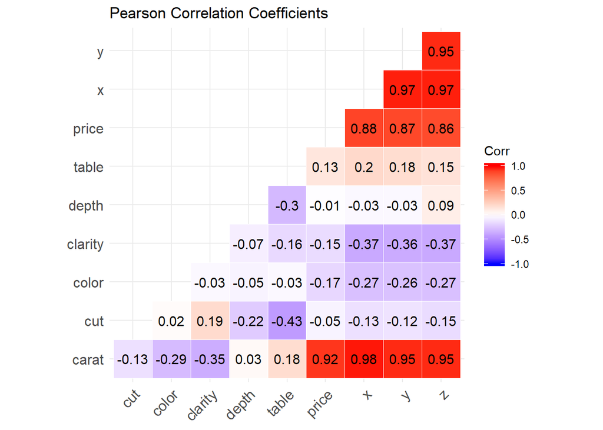

From the above table, we can see high correlations between x,y,z and also between them and variable carat.

#### Creating GGpair to observe Multicollinearity

To confirm that we have Multicollinearity between ‘x’, ‘y’, ‘z’, and Carat, we create a GGpair plot here without considering ‘cut’, ‘color’, ‘clarity’, ‘table’, and ‘depth’.

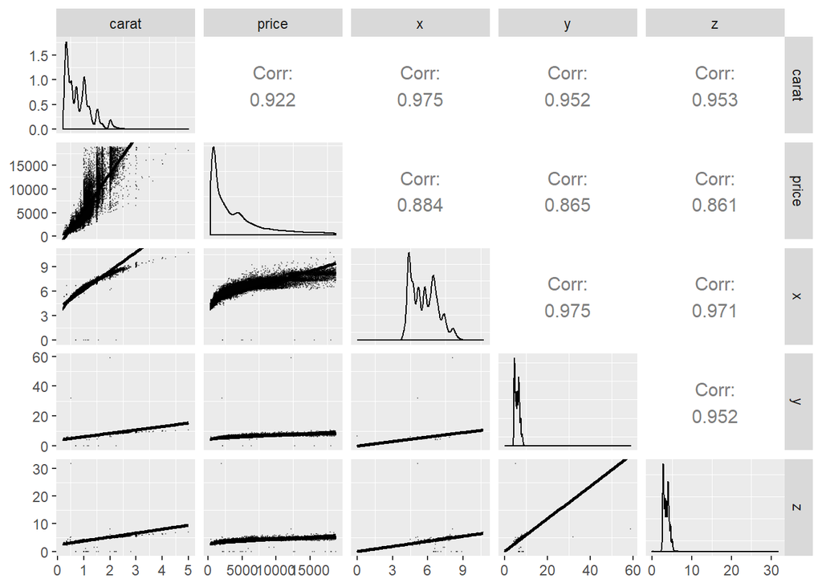

As the result shows, the relationship between these four variables is linear, so we should eliminate x,y, and z from our model.

#### Using variance inflation factor (VIF)

To confirm our result from GGpair plot, we also can use VIF to find correlations between our independent variables.

```
##
## Call:
## imcdiag(x = X, y = diamonds$price, method = "VIF", corr = FALSE)
##
##
##  VIF Multicollinearity Diagnostics
##
##        VIF detection
## V1 22.0000         1
## V2  1.4837         0
## V3  1.1203         0
## V4  1.2270         0
## V5  1.7188         0
## V6  1.5810         0
## V7 56.8976         1
## V8 20.4673         1
## V9 23.5410         1
##
## Multicollinearity may be due to V1 V7 V8 V9 regressors
##
## 1 --> COLLINEARITY is detected by the test
## 0 --> COLLINEARITY is not detected by the test
##
## ===================================
```

The results clearly confirm what we got from the GGpait plot. It means we need to eliminate x,y, and z from our model.

#### Fitting First-Order model

Our first order model will include carat, cut, color, clarity, depth, and table. Here we run the individual t-test to see which one of the predictors are significant and which one we should eliminate from our model.

```
##
## Call:
## lm(formula = price ~ carat + factor(cut) + factor(color) + factor(clarity) +
##     depth + table, data = diamonds)
##
## Residuals:
##      Min       1Q   Median       3Q      Max
## -16828.8   -678.7   -199.4    464.6  10341.2
##
## Coefficients:
##                       Estimate Std. Error t value             Pr(>|t|)
## (Intercept)          -6877.736    374.613 -18.360 < 0.0000000000000002 ***
## carat                 8895.194     12.079 736.390 < 0.0000000000000002 ***
## factor(cut)Good        614.424     34.337  17.894 < 0.0000000000000002 ***
## factor(cut)Very Good   778.428     32.936  23.635 < 0.0000000000000002 ***
## factor(cut)Premium     806.024     32.954  24.459 < 0.0000000000000002 ***
## factor(cut)Ideal       877.569     34.152  25.696 < 0.0000000000000002 ***
## factor(color)I         884.288     26.940  32.825 < 0.0000000000000002 ***
## factor(color)H        1344.591     25.447  52.840 < 0.0000000000000002 ***
## factor(color)G        1815.601     24.828  73.126 < 0.0000000000000002 ***
## factor(color)F        2018.277     25.334  79.668 < 0.0000000000000002 ***
## factor(color)E        2111.716     25.476  82.892 < 0.0000000000000002 ***
## factor(color)D        2322.565     26.715  86.940 < 0.0000000000000002 ***
## factor(clarity)SI2    2619.004     44.788  58.476 < 0.0000000000000002 ***
## factor(clarity)SI1    3567.794     44.587  80.020 < 0.0000000000000002 ***
## factor(clarity)VS2    4210.194     44.840  93.893 < 0.0000000000000002 ***
## factor(clarity)VS1    4525.400     45.547  99.356 < 0.0000000000000002 ***
## factor(clarity)VVS2   4957.310     46.901 105.697 < 0.0000000000000002 ***
## factor(clarity)VVS1   5061.734     48.224 104.964 < 0.0000000000000002 ***
## factor(clarity)IF     5404.237     52.174 103.582 < 0.0000000000000002 ***
## depth                  -21.024      4.079  -5.154          0.000000256 ***
## table                  -24.803      2.978  -8.329 < 0.0000000000000002 ***
## ---
## Signif. codes:  0 '***' 0.001 '**' 0.01 '*' 0.05 '.' 0.1 ' ' 1
##
## Residual standard error: 1156 on 53919 degrees of freedom
## Multiple R-squared:  0.9161, Adjusted R-squared:  0.916
## F-statistic: 2.942e+04 on 20 and 53919 DF,  p-value: < 0.00000000000000022
```

The t-test results show that the p-value for all variables is below 0.05 so all of them are significant.

#### Running Backward Elimination Method

To make sure about our results for the first-order model, we also run one of the stepwise regression methods.

```r
backmodel <- ols_step_backward_p(firstordermodel, prem = 0.3, details = TRUE)
```

```
## Backward Elimination Method
## ---------------------------
##
## Candidate Terms:
##
## 1 . carat
## 2 . factor(cut)
## 3 . factor(color)
## 4 . factor(clarity)
## 5 . depth
## 6 . table
##
## We are eliminating variables based on p value...
##
##
## No more variables satisfy the condition of p value = 0.3
##
##
## Variables Removed:
##
##
##
## Final Model Output
## ------------------
##
##                            Model Summary
## -------------------------------------------------------------------
## R                       0.957       RMSE                  1156.090
## R-Squared               0.916       Coef. Var               29.396
## Adj. R-Squared          0.916       MSE                1336543.872
## Pred R-Squared          0.916       MAE                    803.034
## -------------------------------------------------------------------
##  RMSE: Root Mean Square Error
##  MSE: Mean Square Error
##  MAE: Mean Absolute Error
##
##                                         ANOVA
## --------------------------------------------------------------------------------------
##                         Sum of
##                        Squares           DF        Mean Square        F          Sig.
```

[output cut: 17 more lines]

```
##       factor(color)H     1344.591        25.447        0.122     52.840    0.000     1294.716     1394.467
##       factor(color)G     1815.601        24.828        0.185     73.126    0.000     1766.937     1864.265
##       factor(color)F     2018.277        25.334        0.193     79.668    0.000     1968.623     2067.931
##       factor(color)E     2111.716        25.476        0.204     82.892    0.000     2061.784     2161.648
##       factor(color)D     2322.565        26.715        0.193     86.940    0.000     2270.204     2374.926
##   factor(clarity)SI2     2619.004        44.788        0.247     58.476    0.000     2531.220     2706.788
##   factor(clarity)SI1     3567.794        44.587        0.383     80.020    0.000     3480.404     3655.184
##   factor(clarity)VS2     4210.194        44.840        0.442     93.893    0.000     4122.307     4298.082
##   factor(clarity)VS1     4525.400        45.547        0.407     99.356    0.000     4436.127     4614.673
##  factor(clarity)VVS2     4957.310        46.901        0.362    105.697    0.000     4865.384     5049.237
##  factor(clarity)VVS1     5061.734        48.224        0.319    104.964    0.000     4967.216     5156.253
##    factor(clarity)IF     5404.237        52.174        0.243    103.582    0.000     5301.976     5506.497
##                depth      -21.024         4.079       -0.008     -5.154    0.000      -29.019      -13.028
##                table      -24.803         2.978       -0.014     -8.329    0.000      -30.639      -18.966
## -----------------------------------------------------------------------------------------------------------
```

Again, we can see that the stepwise method also confirmed our t-test result and all the predictors are significant at alpha=0.05.

#### Fitting Full Interaction model

Now, we are going to figure out if there are any meaningful interaction between predictors.

```
##
## Call:
## lm(formula = price ~ (carat + factor(cut) + factor(color) + factor(clarity) +
##     depth + table)^2, data = diamonds)
##
## Residuals:
##     Min      1Q  Median      3Q     Max
## -7415.6  -635.4  -134.5   561.5  7561.5
##
## Coefficients:
##                                            Estimate Std. Error t value
## (Intercept)                               1478.7490  5504.2127   0.269
## carat                                     2248.1742   786.7628   2.857
## factor(cut)Good                           3078.4322  1178.1677   2.613
## factor(cut)Very Good                      2439.6990  1144.6388   2.131
## factor(cut)Premium                       -4100.3137  1151.7441  -3.560
## factor(cut)Ideal                           136.5203  1295.6543   0.105
## factor(color)I                            2105.2844  1718.7014   1.225
## factor(color)H                           -1041.4912  1625.0380  -0.641
## factor(color)G                            -719.4019  1588.7102  -0.453
## factor(color)F                             -66.3701  1612.6019  -0.041
## factor(color)E                           -1673.0044  1611.8421  -1.038
## factor(color)D                           -3795.4549  1719.0198  -2.208
## factor(clarity)SI2                        4785.4318  2162.6903   2.213
## factor(clarity)SI1                        3400.0536  2151.4335   1.580
## factor(clarity)VS2                         445.2186  2178.5256   0.204
## factor(clarity)VS1                        1509.8245  2259.5985   0.668
## factor(clarity)VVS2                      -3750.3781  2426.9989  -1.545
## factor(clarity)VVS1                         66.2783  2597.8430   0.026
## factor(clarity)IF                        -2844.1898  2999.2934  -0.948
## depth                                       40.0794    79.1915   0.506
## table                                     -154.0500    82.3258  -1.871
## carat:factor(cut)Good                     -155.0857    70.2685  -2.207
## carat:factor(cut)Very Good                 207.3840    66.9775   3.096
## carat:factor(cut)Premium                   129.9196    66.5444   1.952
## carat:factor(cut)Ideal                     442.4845    69.5127   6.366
## carat:factor(color)I                       826.4532    42.9377  19.248
## carat:factor(color)H                      1024.9584    41.6383  24.616
## carat:factor(color)G                      1687.7794    41.3039  40.863
## carat:factor(color)F                      2214.0279    44.2767  50.004
```

[output cut: 301 more lines]

```
## factor(clarity)IF:depth                              0.211253
## factor(clarity)SI2:table                             0.000629 ***
## factor(clarity)SI1:table                             0.075280 .
## factor(clarity)VS2:table                             0.500177
## factor(clarity)VS1:table                             0.393682
## factor(clarity)VVS2:table                            0.433929
## factor(clarity)VVS1:table                            0.400730
## factor(clarity)IF:table                              0.743955
## depth:table                                          0.296877
## ---
## Signif. codes:  0 '***' 0.001 '**' 0.01 '*' 0.05 '.' 0.1 ' ' 1
##
## Residual standard error: 1002 on 53771 degrees of freedom
## Multiple R-squared:  0.9371, Adjusted R-squared:  0.9369
## F-statistic:  4771 on 168 and 53771 DF,  p-value: < 0.00000000000000022
```

#### Fitting Reduced Interaction model without depth*table term

So, from last part, we drop depth*table and create the reduced interaction model here.

```
##
## Call:
## lm(formula = price ~ carat + factor(cut) + factor(color) + factor(clarity) +
##     depth + table + carat * factor(cut) + carat * factor(color) +
##     carat * factor(clarity) + carat * depth + carat * table +
##     factor(cut) * factor(color) + factor(cut) * factor(clarity) +
##     factor(cut) * depth + factor(cut) * table + factor(color) *
##     factor(clarity) + factor(color) * depth + factor(color) *
##     table + factor(clarity) * depth + factor(clarity) * table,
##     data = diamonds)
##
## Residuals:
##     Min      1Q  Median      3Q     Max
## -7414.3  -635.3  -134.3   561.2  7562.0
##
## Coefficients:
##                                            Estimate Std. Error t value
## (Intercept)                              -3503.0667  2736.6563  -1.280
## carat                                     2280.4932   786.1532   2.901
## factor(cut)Good                           3257.5639  1165.5873   2.795
## factor(cut)Very Good                      2792.8743  1093.4239   2.554
## factor(cut)Premium                       -3756.8242  1103.6727  -3.404
## factor(cut)Ideal                           662.4765  1193.5292   0.555
## factor(color)I                            2087.4626  1718.6179   1.215
## factor(color)H                           -1039.0581  1625.0376  -0.639
## factor(color)G                            -671.8557  1588.0576  -0.423
## factor(color)F                             -35.1157  1612.3248  -0.022
## factor(color)E                           -1688.7857  1611.7724  -1.048
## factor(color)D                           -3783.4879  1718.9829  -2.201
## factor(clarity)SI2                        4722.3635  2161.8469   2.184
## factor(clarity)SI1                        3376.2867  2151.3147   1.569
## factor(clarity)VS2                         390.9104  2177.9052   0.179
## factor(clarity)VS1                        1493.7527  2259.5478   0.661
## factor(clarity)VVS2                      -3744.4210  2426.9942  -1.543
## factor(clarity)VVS1                         94.7137  2597.7021   0.036
## factor(clarity)IF                        -2789.5065  2998.8377  -0.930
## depth                                      117.4593    27.7292   4.236
## table                                      -71.8644    23.8848  -3.009
## carat:factor(cut)Good                     -152.2600    70.2163  -2.168
## carat:factor(cut)Very Good                 208.9783    66.9601   3.121
```

[output cut: 305 more lines]

```
## factor(clarity)VVS1:depth                            0.004146 **
## factor(clarity)IF:depth                              0.219624
## factor(clarity)SI2:table                             0.000533 ***
## factor(clarity)SI1:table                             0.066409 .
## factor(clarity)VS2:table                             0.470593
## factor(clarity)VS1:table                             0.360078
## factor(clarity)VVS2:table                            0.470262
## factor(clarity)VVS1:table                            0.439663
## factor(clarity)IF:table                              0.790772
## ---
## Signif. codes:  0 '***' 0.001 '**' 0.01 '*' 0.05 '.' 0.1 ' ' 1
##
## Residual standard error: 1002 on 53772 degrees of freedom
## Multiple R-squared:  0.9371, Adjusted R-squared:  0.9369
## F-statistic:  4800 on 167 and 53772 DF,  p-value: < 0.00000000000000022
```

So, until this point, our final model is the reduced interaction model.

### Assumptions

Now that we have a model that we think might be a proper model to predict the diamonds price, we can go to the next step and test the model against the below assumptions to see if the model needs more improvement or not.

- There is a linear relationship between the predictors and the response.
- Multicollinearity is not present, predictors are not too highly correlated with each other. (We did this test at the first step and removed x,y, and z from our predictors).
- Heteroscedasticity is not present, or there are constant variances in the errors.
- Residuals are Normally distributed, N(0,1).

*We tried to do Shapiro-Wilk test but our dataset has more than 5000 points that’s why we can not apply this test to check for normality.

#### Plotting to check for linearity and Homoscedasticity

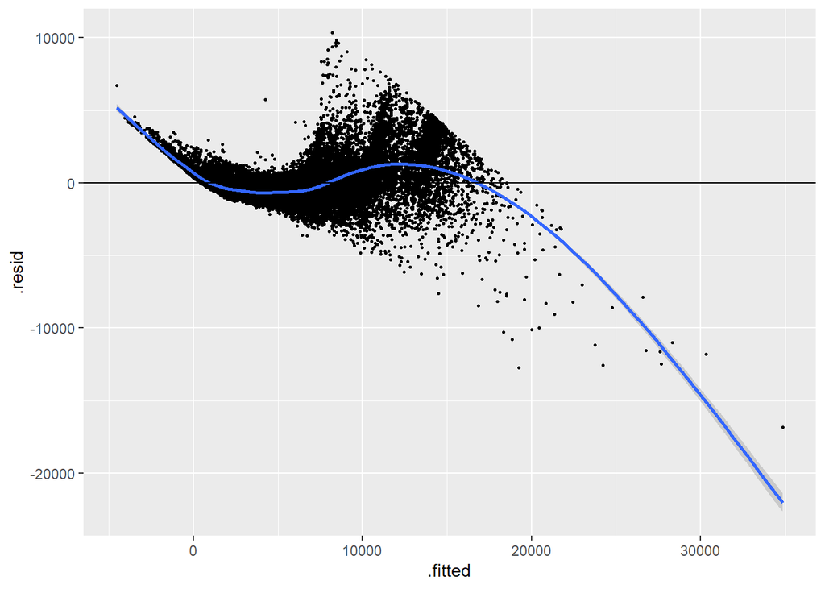

We can clearly see that the first-order model fails the linearity test. We also can see the funnel shape which indicates heteroscedasticity.

#### Test for Homoscedasticity

To confirm the heteroscedasticity, we can use Breusch-Pagan test here on our first-order model as well.

```r
bptest(firstordermodel)
```

```
##
##  studentized Breusch-Pagan test
##
## data:  firstordermodel
## BP = 8829.3, df = 20, p-value < 0.00000000000000022
```

The output displays the Breusch-Pagan test result for the first-order model. The p-value <0.05, indicating that we do reject the null hypothesis. Which means, the test provides evidence to suggest that heteroscedasticity does exist.

#### Plotting to check for linearity and Homoscedasticity

Now we perform the same tests on our Reduced Iteraction model. First checking linearity;

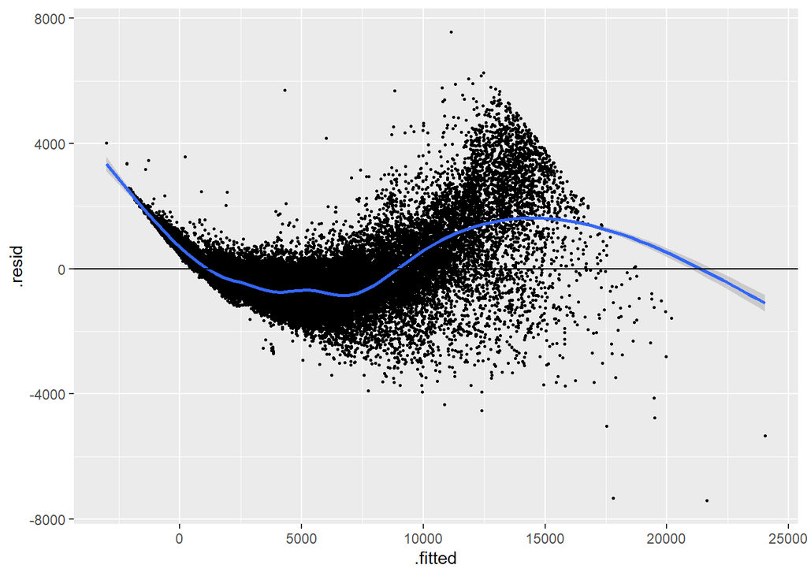

In terms of linearity, as the plot shows, this model performs better than the first-order model, but still needs improvement. We also still can see the funnel shape which indicates heteroscedasticity.

#### Test for Homoscedasticity

To confirm the heteroscedasticity, we use Breusch-Pagan test here on the reduced interaction model as well.

```r
bptest(reducedintermodel)
```

```
##
##  studentized Breusch-Pagan test
##
## data:  reducedintermodel
## BP = 12054, df = 167, p-value < 0.00000000000000022
```

The Breusch-Pagan test result for the reduced-interaction model. The p-value <0.05, indicating that we do reject the null hypothesis. This means, also in the interaction model, we have heteroscedasticity.

#### Plotting to check for possible high order terms

So, by far, per the result of linearity and Homoscedasticity tests, none of the models are proper enough for prediction. Thus we go further and try high-order terms.

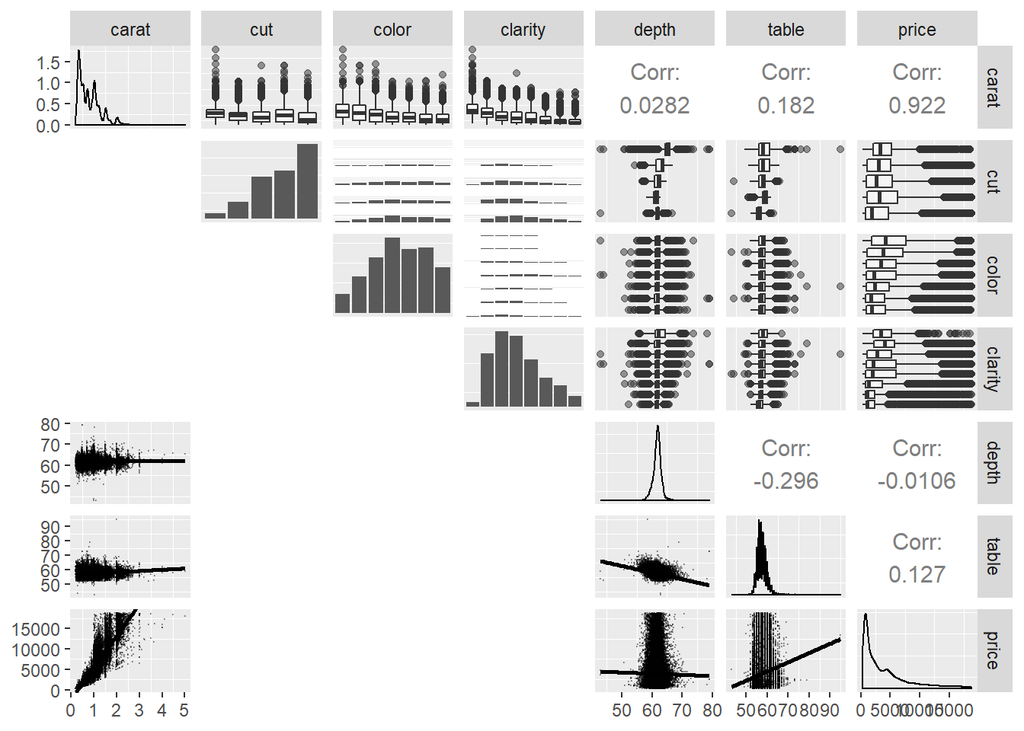

As the plot displays, we may have a polynomial relation between price and carat. So we go ahead and check it in the next step.

#### Fitting polynomial (high-order) model for `carat`

```
##
## Call:
## lm(formula = price ~ poly(carat, 13, raw = TRUE) + factor(cut) +
##     factor(color) + factor(clarity) + depth + table + carat *
##     factor(cut) + carat * factor(color) + carat * factor(clarity) +
##     carat * depth + carat * table + factor(cut) * factor(color) +
##     factor(cut) * factor(clarity) + factor(cut) * depth + factor(cut) *
##     table + factor(color) * factor(clarity) + factor(color) *
##     depth + factor(color) * table + factor(clarity) * depth +
##     factor(clarity) * table, data = diamonds)
##
## Residuals:
##     Min      1Q  Median      3Q     Max
## -9520.7  -204.9    20.3   229.0  7885.8
##
## Coefficients: (1 not defined because of singularities)
##                                               Estimate    Std. Error
## (Intercept)                                  8160.1405     2250.9546
## poly(carat, 13, raw = TRUE)1              -185754.5685    16713.4933
## poly(carat, 13, raw = TRUE)2              1027544.3012    89066.2282
## poly(carat, 13, raw = TRUE)3             -3226534.2231   266217.4129
## poly(carat, 13, raw = TRUE)4              6287559.0452   499676.6095
## poly(carat, 13, raw = TRUE)5             -7995209.7712   624904.7691
## poly(carat, 13, raw = TRUE)6              6873788.0222   538520.4844
## poly(carat, 13, raw = TRUE)7             -4082953.1759   325484.2567
## poly(carat, 13, raw = TRUE)8              1691031.6639   138681.9931
## poly(carat, 13, raw = TRUE)9              -486394.5360    41341.8277
## poly(carat, 13, raw = TRUE)10               95139.7800     8419.2635
## poly(carat, 13, raw = TRUE)11              -12060.5105     1113.8330
## poly(carat, 13, raw = TRUE)12                 892.8873       86.1249
## poly(carat, 13, raw = TRUE)13                 -29.2910        2.9497
## factor(cut)Good                              -543.8053      772.9734
## factor(cut)Very Good                         1328.8852      725.1055
## factor(cut)Premium                          -2297.4304      731.7773
## factor(cut)Ideal                              428.8273      791.4511
## factor(color)I                                343.2917     1139.6063
## factor(color)H                              -1598.5736     1077.7399
## factor(color)G                              -3574.8077     1053.3865
## factor(color)F                              -2811.9979     1069.2878
## factor(color)E                              -3630.6749     1068.8780
```

[output cut: 331 more lines]

```
## factor(clarity)VVS1:depth                 -5.279   0.0000001304950002 ***
## factor(clarity)IF:depth                   -2.845             0.004441 **
## factor(clarity)SI2:table                  -5.180   0.0000002226561691 ***
## factor(clarity)SI1:table                  -5.251   0.0000001514385005 ***
## factor(clarity)VS2:table                  -5.656   0.0000000155642768 ***
## factor(clarity)VS1:table                  -6.084   0.0000000011770400 ***
## factor(clarity)VVS2:table                 -5.340   0.0000000931662433 ***
## factor(clarity)VVS1:table                 -6.042   0.0000000015330508 ***
## factor(clarity)IF:table                   -4.568   0.0000049308960813 ***
## ---
## Signif. codes:  0 '***' 0.001 '**' 0.01 '*' 0.05 '.' 0.1 ' ' 1
##
## Residual standard error: 664 on 53760 degrees of freedom
## Multiple R-squared:  0.9724, Adjusted R-squared:  0.9723
## F-statistic: 1.058e+04 on 179 and 53760 DF,  p-value: < 0.00000000000000022
```

By adding high-order terms for carat to the reduced-interaction model and making poly-reduced-intermodel, we get the Adjusted R-squared: 0.9723 which is the best so far. Also, all the polynomials are significant.

#### Check again for linearity and homoscedasticity in High-Order Interaction model

Now we test our new model to see how good it is!

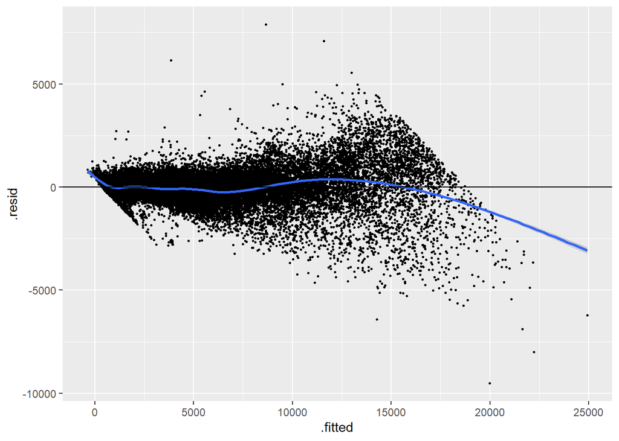

This result looks much better than the previous models in terms of linearity, But still, the funnel shape from left to the right is visible and Heteroscedasticity exists. Let’s also check homoscedasticity for the poly-reduced-interaction model though Breusch-Pagan test;

```r
bptest(polyreducedintermodel)
```

```
##
##  studentized Breusch-Pagan test
##
## data:  polyreducedintermodel
## BP = 17091, df = 179, p-value < 0.00000000000000022
```

The result confirms in terms of homoscedasticity, we still have got the problem and Heteroscedasticity exists.

#### Plotting Histogram to check for normality

Before going any further, for our last model (poly-reduced-intermodel), Let’s check the normality assumption.

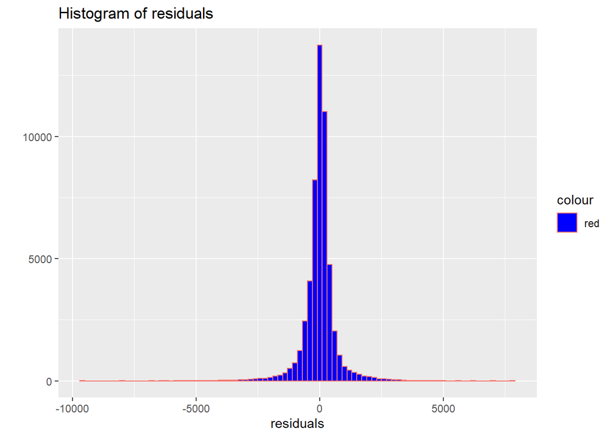

The histogram looks normal. Now checking QQ plot.

#### Plotting QQ to check for normality

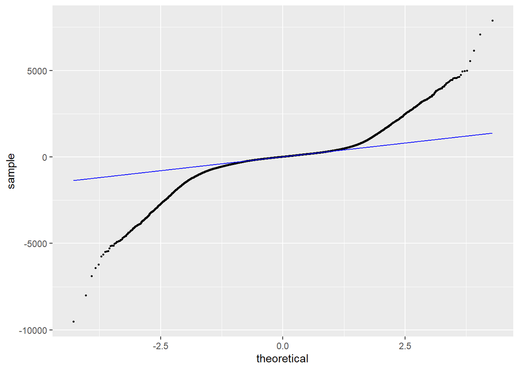

Unfortunately it does not look good enough! It means, The output shows that the residual data have not Normaly distributed.

### Taking A New Approach, Log Transformation

#### Log Transforming Diamonds

Here, we start transforming all the models we got from beginning to the Log model to see which one can satisfy the assumptions as of the best-fitted model. First we transform the response (Price) and quantitative predictors (Carat, Table, and Depth);

|  | carat | cut | color | clarity | depth | table | price | x | y | z |
| --- | --- | --- | --- | --- | --- | --- | --- | --- | --- | --- |
| 1 | -1.469676 | Ideal | E | SI2 | 4.119037 | 4.007333 | 5.786897 | 3.95 | 3.98 | 2.43 |
| 2 | -1.560648 | Premium | E | SI1 | 4.091006 | 4.110874 | 5.786897 | 3.89 | 3.84 | 2.31 |
| 3 | -1.469676 | Good | E | VS1 | 4.041295 | 4.174387 | 5.789960 | 4.05 | 4.07 | 2.31 |
| 4 | -1.237874 | Premium | I | VS2 | 4.133565 | 4.060443 | 5.811141 | 4.20 | 4.23 | 2.63 |
| 5 | -1.171183 | Good | J | SI2 | 4.147885 | 4.060443 | 5.814131 | 4.34 | 4.35 | 2.75 |
| 6 | -1.427116 | Very Good | J | VVS2 | 4.139955 | 4.043051 | 5.817111 | 3.94 | 3.96 | 2.48 |

#### Fitting Log transformed First-Order model

```
##
## Call:
## lm(formula = price ~ carat + factor(cut) + factor(color) + factor(clarity) +
##     depth + table, data = diamonds_log)
##
## Residuals:
##      Min       1Q   Median       3Q      Max
## -1.01116 -0.08640 -0.00030  0.08347  1.94208
##
## Coefficients:
##                       Estimate Std. Error  t value            Pr(>|t|)
## (Intercept)           7.583969   0.170291   44.535 <0.0000000000000002 ***
## carat                 1.883759   0.001135 1659.779 <0.0000000000000002 ***
## factor(cut)Good       0.078885   0.003961   19.916 <0.0000000000000002 ***
## factor(cut)Very Good  0.115539   0.003784   30.529 <0.0000000000000002 ***
## factor(cut)Premium    0.137417   0.003783   36.325 <0.0000000000000002 ***
## factor(cut)Ideal      0.159071   0.003914   40.641 <0.0000000000000002 ***
## factor(color)I        0.138393   0.003117   44.402 <0.0000000000000002 ***
## factor(color)H        0.259880   0.002940   88.405 <0.0000000000000002 ***
## factor(color)G        0.350534   0.002861  122.501 <0.0000000000000002 ***
## factor(color)F        0.416251   0.002916  142.756 <0.0000000000000002 ***
## factor(color)E        0.456569   0.002932  155.712 <0.0000000000000002 ***
## factor(color)D        0.510852   0.003075  166.131 <0.0000000000000002 ***
## factor(clarity)SI2    0.427598   0.005181   82.534 <0.0000000000000002 ***
## factor(clarity)SI1    0.592732   0.005151  115.079 <0.0000000000000002 ***
## factor(clarity)VS2    0.741884   0.005181  143.204 <0.0000000000000002 ***
## factor(clarity)VS1    0.811933   0.005261  154.324 <0.0000000000000002 ***
## factor(clarity)VVS2   0.946927   0.005423  174.623 <0.0000000000000002 ***
## factor(clarity)VVS1   1.018380   0.005580  182.511 <0.0000000000000002 ***
## factor(clarity)IF     1.113249   0.006038  184.375 <0.0000000000000002 ***
## depth                -0.045311   0.028795   -1.574               0.116
## table                -0.012113   0.020068   -0.604               0.546
## ---
## Signif. codes:  0 '***' 0.001 '**' 0.01 '*' 0.05 '.' 0.1 ' ' 1
##
## Residual standard error: 0.1338 on 53919 degrees of freedom
## Multiple R-squared:  0.9826, Adjusted R-squared:  0.9826
## F-statistic: 1.524e+05 on 20 and 53919 DF,  p-value: < 0.00000000000000022
```

#### Fitting Log transformed Reduced First-Order model without `depth` and `table`

```
##
## Call:
## lm(formula = price ~ carat + factor(cut) + factor(color) + factor(clarity),
##     data = diamonds_log)
##
## Residuals:
##      Min       1Q   Median       3Q      Max
## -1.01107 -0.08636 -0.00023  0.08341  1.94778
##
## Coefficients:
##                      Estimate Std. Error t value            Pr(>|t|)
## (Intercept)          7.345873   0.006039 1216.33 <0.0000000000000002 ***
## carat                1.883718   0.001129 1668.75 <0.0000000000000002 ***
## factor(cut)Good      0.080048   0.003890   20.57 <0.0000000000000002 ***
## factor(cut)Very Good 0.117215   0.003619   32.39 <0.0000000000000002 ***
## factor(cut)Premium   0.139345   0.003579   38.94 <0.0000000000000002 ***
## factor(cut)Ideal     0.161218   0.003548   45.44 <0.0000000000000002 ***
## factor(color)I       0.138409   0.003117   44.41 <0.0000000000000002 ***
## factor(color)H       0.259912   0.002940   88.42 <0.0000000000000002 ***
## factor(color)G       0.350605   0.002861  122.55 <0.0000000000000002 ***
## factor(color)F       0.416387   0.002915  142.87 <0.0000000000000002 ***
## factor(color)E       0.456706   0.002931  155.84 <0.0000000000000002 ***
## factor(color)D       0.510983   0.003074  166.24 <0.0000000000000002 ***
## factor(clarity)SI2   0.427879   0.005178   82.64 <0.0000000000000002 ***
## factor(clarity)SI1   0.592954   0.005149  115.17 <0.0000000000000002 ***
## factor(clarity)VS2   0.742164   0.005178  143.34 <0.0000000000000002 ***
## factor(clarity)VS1   0.812277   0.005257  154.52 <0.0000000000000002 ***
## factor(clarity)VVS2  0.947271   0.005418  174.83 <0.0000000000000002 ***
## factor(clarity)VVS1  1.018743   0.005575  182.73 <0.0000000000000002 ***
## factor(clarity)IF    1.113732   0.006030  184.69 <0.0000000000000002 ***
## ---
## Signif. codes:  0 '***' 0.001 '**' 0.01 '*' 0.05 '.' 0.1 ' ' 1
##
## Residual standard error: 0.1338 on 53921 degrees of freedom
## Multiple R-squared:  0.9826, Adjusted R-squared:  0.9826
## F-statistic: 1.693e+05 on 18 and 53921 DF,  p-value: < 0.00000000000000022
```

#### Fitting Log transformed Full Interaction model

The depth variable had the p-value of 0.116 in the first-order model, that’s why we eliminated it from the reduced model but since we might get a proper react in the interaction model from it (its p-value is not too far from 0.1), we are going to add it here and check the results.

```
##
## Call:
## lm(formula = price ~ (carat + depth + factor(cut) + factor(color) +
##     factor(clarity))^2, data = diamonds_log)
##
## Residuals:
##      Min       1Q   Median       3Q      Max
## -0.78560 -0.07885  0.00213  0.07693  1.61976
##
## Coefficients:
##                                            Estimate Std. Error t value
## (Intercept)                               9.3836009  0.7130485  13.160
## carat                                     3.7291128  0.2153131  17.319
## depth                                    -0.4306488  0.1703418  -2.528
## factor(cut)Good                          -1.3994077  0.3116236  -4.491
## factor(cut)Very Good                     -1.5956785  0.3144371  -5.075
## factor(cut)Premium                       -2.5172195  0.3256075  -7.731
## factor(cut)Ideal                          0.2110922  0.3816384   0.553
## factor(color)I                            0.8840415  0.5269204   1.678
## factor(color)H                            0.6800690  0.4992863   1.362
## factor(color)G                            0.1276755  0.4856916   0.263
## factor(color)F                            2.2675106  0.4907425   4.621
## factor(color)E                            1.3506641  0.4902991   2.755
## factor(color)D                            0.7514671  0.5223519   1.439
## factor(clarity)SI2                       -0.3426947  0.6202871  -0.552
## factor(clarity)SI1                       -0.2004516  0.6162059  -0.325
## factor(clarity)VS2                       -0.8348446  0.6254703  -1.335
## factor(clarity)VS1                       -0.1721561  0.6492689  -0.265
## factor(clarity)VVS2                       0.4244091  0.7169465   0.592
## factor(clarity)VVS1                      -0.2896592  0.7862627  -0.368
## factor(clarity)IF                        -0.2782727  0.9485638  -0.293
## carat:depth                              -0.5371299  0.0516209 -10.405
## carat:factor(cut)Good                     0.0612756  0.0086895   7.052
## carat:factor(cut)Very Good                0.0678257  0.0083622   8.111
## carat:factor(cut)Premium                 -0.0160957  0.0083867  -1.919
## carat:factor(cut)Ideal                    0.0560114  0.0082643   6.777
## carat:factor(color)I                      0.0177516  0.0052456   3.384
## carat:factor(color)H                      0.0213656  0.0049998   4.273
## carat:factor(color)G                      0.0755468  0.0048469  15.586
## carat:factor(color)F                      0.0961596  0.0050365  19.092
```

[output cut: 261 more lines]

```
## factor(color)F:factor(clarity)VVS1       < 0.0000000000000002 ***
## factor(color)E:factor(clarity)VVS1       < 0.0000000000000002 ***
## factor(color)D:factor(clarity)VVS1       < 0.0000000000000002 ***
## factor(color)I:factor(clarity)IF                     0.000332 ***
## factor(color)H:factor(clarity)IF         < 0.0000000000000002 ***
## factor(color)G:factor(clarity)IF         < 0.0000000000000002 ***
## factor(color)F:factor(clarity)IF         < 0.0000000000000002 ***
## factor(color)E:factor(clarity)IF         < 0.0000000000000002 ***
## factor(color)D:factor(clarity)IF         < 0.0000000000000002 ***
## ---
## Signif. codes:  0 '***' 0.001 '**' 0.01 '*' 0.05 '.' 0.1 ' ' 1
##
## Residual standard error: 0.1239 on 53791 degrees of freedom
## Multiple R-squared:  0.9851, Adjusted R-squared:  0.9851
## F-statistic: 2.406e+04 on 148 and 53791 DF,  p-value: < 0.00000000000000022
```

#### Plotting Histogram and QQ to check for normality

Let’s check for Normality assumption for the log-interaction model;

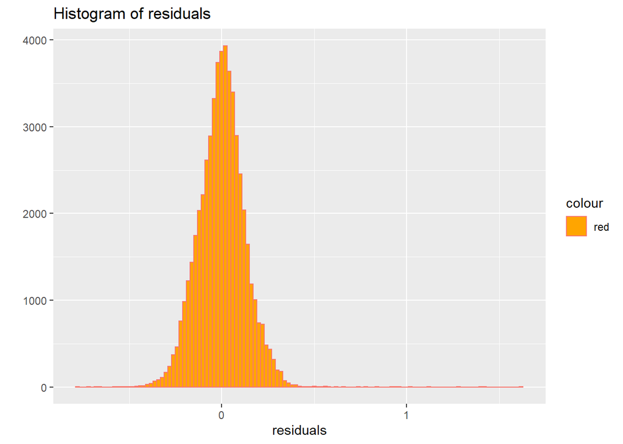

```r
plot_hist_normality <- qplot(residuals(interlog),
                              geom="histogram",
                              binwidth = 0.02,
                              main = "Histogram of residuals",
                              xlab = "residuals", color="red",
                              fill=I("orange"))
print(plot_hist_normality)
```

The histogram shows that the residuals are almost normaly distributed.

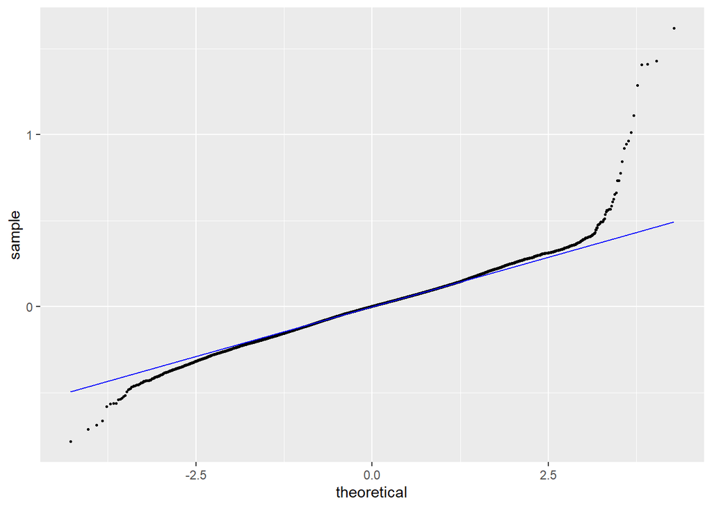

We definitely can observe a lot of improvement form the poly-interaction model to this log-interaction model. Other than some points at the both ends, the data points are almost laid on the line which shows it is close to a normal distribution.

#### Plotting to check for linearity and homoscedasticity using the log-interaction model

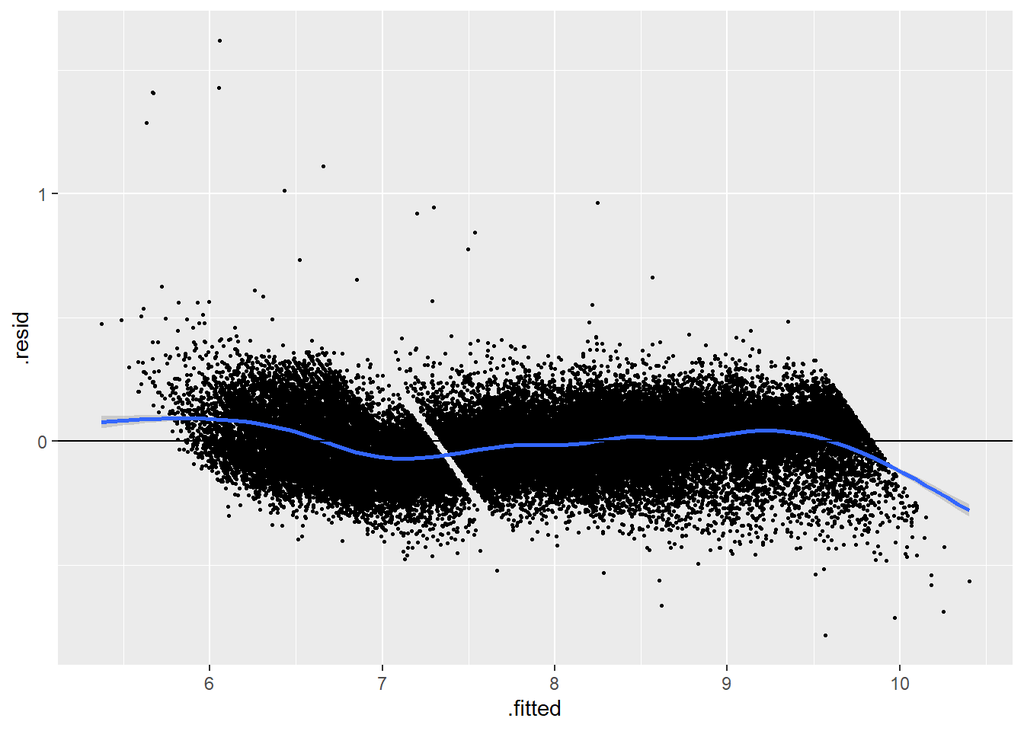

We have another improvment here! No funnel observed this time. The residuals tend to form a horizontal band, indicates that the plot does not provide evidence to suggest that heteroscedasticity exists. Also the blue line has a pretty good strech over the horizental line which shows the linearity.

#### Plotting to check for possible high order terms

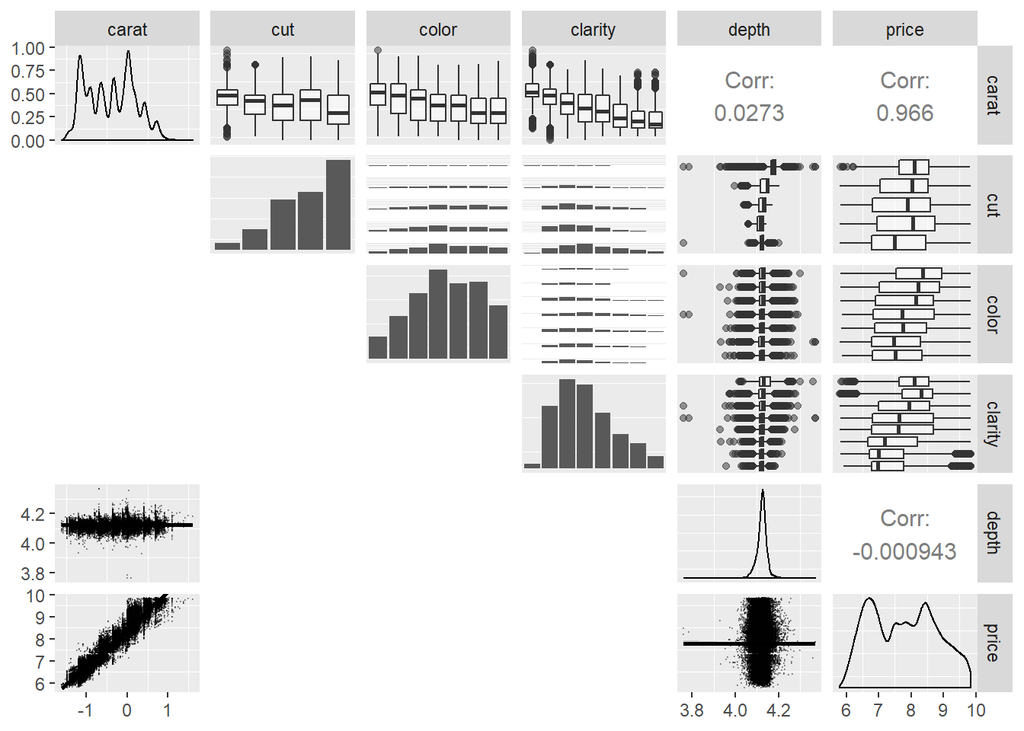

And here, we can not see any curve between depth and carat with the price. This confirms that there is no need to go for a higher-terms model within the log.

#### Printing Outliers using the latest model for the log transformed data

No let’s see if we can find any outliers in our dataset;

```
##  [1] carat   cut     color   clarity depth   table   price   x
##  [9] y       z
## <0 rows> (or 0-length row.names)
```

None! good then :)

#### Prediction

Let’s do some predections based on our final model here;

```r
carat1.00 = data.frame(carat=log(1.00), color="G", clarity="SI1", cut="Ideal", table=log(56), depth=log(62.7))
carat1.01 = data.frame(carat=log(1.01), color="G", clarity="SI1", cut="Ideal", table=log(56), depth=log(62.7))
r1 = predict(interlog, carat1.00, type="response")
r2 = predict(interlog, carat1.01, type="response")
cat("Predicted log(price) of a diamond of carat 1.00 is", r1, "which translates to exp(", r1, ") =", exp(r1), "$\n")
```

```
## Predicted log(price) of a diamond of carat 1.00 is 8.445415 which translates to exp( 8.445415 ) = 4653.686 $
```

```r
cat("Predicted log(price) of a diamond of carat 1.01 is", r2, "which translates to exp(", r2, ") =", exp(r2), "$\n")
```

```
## Predicted log(price) of a diamond of carat 1.01 is 8.464531 which translates to exp( 8.464531 ) = 4743.503 $
```

### Conclusion

#### Best fit model

The best interaction model, `interlog`, is fitted for the log-transformed diamonds dataset. `diamonds_log`. And the best high-order interaction model, `polyreducedintermodel` is fitted for the `diamonds` dataset, however the correlation between the various predictors and response variable `price` does not seem to be linear or satisfy the normality, linearity and homoscedasticity assumptions, therefore the model for the log transformed data is preferred for prediction because it performs better. Our last model or Log-Interaction model also has the highest $R^2adj$ and lowest RMSE among other models which confirms that it is better than other models not only in terms of passing assumptions but also in terms of being a better predicting model. So our best fit model is;

$$\widehat{Log(Price)} = log(carat) + log(depth) + cut + color + clarity + log(carat)*depth + log(carat)*cut + log(carat)*color +\\ log(carat)*clarity + log(depth)*cut + log(depth)*color + log(depth)*clarity + cut*color + cut*clarity + color*clarity$$

#### Interpret the effects of each independent variable

Since our last model is the log-interaction model, we are going to interpret in terms of our reduced-interaction model.

$$\widehat{Price} = -3503.06+2280.49*carat+117.45*depth + 662.47\ (when\ factor(cut)=Ideal)\\ -3783.48 (when\ factor(color)= D) -2789.50\ (when\ factor(clarity)=IF) -52.30*carat * depth \\+ carat * 442.67\ (when\ factor(cut)=Ideal) + carat * 1919.49 (when\ factor(color)=D)\\+carat *6750.50(when\ factor(clarity)=IF)+ depth*13.10(when\ factor(cut)=Ideal) + depth*-40.21(when\ factor(clarity)=IF)\\ + depth* 0.51(when\ factor(color)=D) + 331.31(when\ factor(cut)=Ideal and factor(color)=D)\\ + 1093.64(when\ factor(cut)=Ideal and factor(clarity)=IF) + 5551.7(when factor(color)=D and factor(clarity)=IF)$$
We assume all other variables to be held when we interpret each of them.

Carat(quantitative): In addition to increasing the price of the diamond by 2280.49 dollars per carat, the carat quantitative variable also has interaction terms with depth, cut, color, and clarity. If we take for example the best possible values for each qualitative variable (i.e. cut = ideal, color = D, clarity = IF), we can see that the interaction terms contributes an additional 442.67 dollars per carat for ideal cut, 1919.49 dollars per carat for best colour, and 6750.50 dollars for best clarity. As well, the interaction term between carat and depth shows that there is a decrease in price of 52.30 dollars per carat per mm depth.

Depth(quantitative): In addition to increasing the price of the diamond by 117.45 dollars per mm depth, the depth quantitative variable also has interaction terms with carat, cut, color and clarity. If we take for example the best possible values for each qualitative variable (i.e. cut = ideal, color = D, clarity = IF), we can see that the interaction terms contributes an additional 13.10 dollars per mm depth for ideal cut, 0.51 dollars per mm depth for best colour, and -40.21 dollars per mm depth for best clarity. As well, the interaction term between carat and depth shows that there is a decrease in price of 52.30 dollars per carat per mm depth.

Cut(qualitative): As cut is a qualitative term, it provides a flat change to the value of the diamond of 662.47 dollars (for the best quality cut, other qualities will have different flat changes), along with having interaction terms with quantitative variables carat and depth (their effects with cut are described above), and qualitative variables clarity and colour. When the colour is the best quality, having the best quality cut increases the diamond’s value by 331.31 dollars. When the clarity is the best quality, having the best quality cut increases the diamond’s value by 1093.64 dollars.

Color(qualitative): As colour is a qualitative term, it provides a flat change to the value of the diamond of -3783.48 dollars (for the best quality colour, other qualities will have different flat changes), along with having interaction terms with quantitative variables carat and depth (their effects with colour are described above), and qualitative variables clarity and cut. When the cut is the best quality, having the best quality colour increases the diamond’s value by 331.31 dollars. When the clarity is the best quality, having the best quality colour increases the diamond’s value by 5551.70 dollars.

Clarity(qualitative): As clarity is a qualitative term, it provides a flat change to the value of the diamond of -2789.50 dollars (for the best quality clarity, other qualities will have different flag changes), along with having interaction terms with quantitative variables carat and depth (their effects with cut are described above), and qualitative variables cut and colour. When cut is the best quality, having the best quality clarity increases the diamond’s value by 1093.64 dollars. When colour is the best quality, having the best clarity will increase the diamond’s value by 5551.70 dollars.

#### $R^2adj$ ,and RMSE

Here we’ve brought all the values for $R^2adj$ ,and RMSE for our models to compare them we each other.

**First-order model:** RMSE: 1156 on 53919 degrees of freedom Adjusted R-squared: 0.916 p-value: < 0.00000000000000022

**Reduced-Interaction Model**: RMSE: 1002 on 53772 degrees of freedom Adjusted R-squared: 0.9369 p-value: < 0.00000000000000022

**High-order model:** RMSE: 664 on 53760 degrees of freedom Adjusted R-squared: 0.9723 p-value: < 0.00000000000000022

**Log-transformed Reduced-First-Order model:** RMSE: 0.1338 on 53921 degrees of freedom Adjusted R-squared: 0.9826 p-value: < 0.00000000000000022

**Log-transformed interaction model:** RMSE: 0.1239 on 53791 degrees of freedom Adjusted R-squared: 0.9851 p-value: < 0.00000000000000022

As we can see, each model has an improvement in terms of $R^2adj$ (increasing) and RMSE (decreasing) from its previous model until we reach the last model or our best-fitted model that also has passed the assumptions regarding normality, linearity, and homoscedasticity.

$R^2adj$ shows how well our data points fall within the line of the regression equation. In our case, the best-fitted model has $R^2adj$ of 0.9851 which says that the price or our dependent variable variance is explained really good by our independent variables in the regression model.

About RMSE in our best-fitted model (0.1239) which shows the differences between predicted values by our model and the values observed, Of-course the lower is the better and we can see the in the last two models where both are log-models, the interaction model got a lower RMSE that shows the prediction is closer to the observed values.

#### Discussions

In this project, we tried to fit the best possible model on our diamond dataset. We started with the first-order model and went on all the way to log models because we could not get a statistically proper model out of the non-log models. None of the models even the high-order model could be able to satisfy the linearity, normality and homoscedasticity assumptions but the interaction-log model, we also did not find any outliers in the dataset which influence our model.

Since we’ve never improved a model to its log before, it was a little out of our comfort zone and also exiting but we are happy that we finally could get a proper model that can relly on for predicting the price of diamonds based on some statistically significant predictors.

A possible improvement to our model, would be to investigate other concave transformation function apart from the log(), but indeed it does not seem easy to work with such a model. Although we should be aware that the $R^2adj$ we got in our best model is very high and that makes it harder to get a significantly better model over the one we already have.